# Stat558_Project3_CartronKaranjai

Matthieu Cartron and Sneha Karanjai

11/11/2022

# Setup

Note: to hide later if necessary.

## Libraries

```r
library(tidyverse)
library(caret)
library(brainGraph)
library(corrplot)
library(GGally)
```

# Data

```r
unzippedNewDataCSV <- unzip("OnlineNewsPopularity.zip")

newsDataName <- read_csv(unzippedNewDataCSV[1]) # This is the names file
newsData <- read_csv(unzippedNewDataCSV[2])

head(newsData)
```

```
## # A tibble: 6 × 61
##   url                  timedelta n_tokens_title n_tokens_content n_unique_tokens
##   <chr>                    <dbl>          <dbl>            <dbl>           <dbl>
## 1 http://mashable.com…       731             12              219           0.664
## 2 http://mashable.com…       731              9              255           0.605
## 3 http://mashable.com…       731              9              211           0.575
## 4 http://mashable.com…       731              9              531           0.504
## 5 http://mashable.com…       731             13             1072           0.416
## 6 http://mashable.com…       731             10              370           0.560
## # … with 56 more variables: n_non_stop_words <dbl>,
## #   n_non_stop_unique_tokens <dbl>, num_hrefs <dbl>, num_self_hrefs <dbl>,
## #   num_imgs <dbl>, num_videos <dbl>, average_token_length <dbl>,
## #   num_keywords <dbl>, data_channel_is_lifestyle <dbl>,
## #   data_channel_is_entertainment <dbl>, data_channel_is_bus <dbl>,
## #   data_channel_is_socmed <dbl>, data_channel_is_tech <dbl>,
## #   data_channel_is_world <dbl>, kw_min_min <dbl>, kw_max_min <dbl>, …
```

```r
newsData %>%
  select(starts_with("data_channel_is_"))
```

```
## # A tibble: 39,644 × 6
##    data_channel_is_lifestyle data_channel_is_… data_channel_is… data_channel_is…
##                        <dbl>             <dbl>            <dbl>            <dbl>
##  1                         0                 1                0                0
##  2                         0                 0                1                0
##  3                         0                 0                1                0
##  4                         0                 1                0                0
##  5                         0                 0                0                0
##  6                         0                 0                0                0
##  7                         1                 0                0                0
##  8                         0                 0                0                0
##  9                         0                 0                0                0
## 10                         0                 0                0                0
## # … with 39,634 more rows, and 2 more variables: data_channel_is_tech <dbl>,
## #   data_channel_is_world <dbl>
```

The 6 groups to analyze are :

- Lifestyle
- Entertainment
- Business
- Social Media
- Technology
- World

We will filter the data to analyze articles in one data channel at a time. Additionally according to the data report, `url` and `timedelta` are two non-predictive columns so we will remove them.

```r
subsettingData <- function(data, area){
  #getting the naming convention as per the dataframe
  key <- ifelse(tolower(area)=="lifestyle", "lifestyle",
                ifelse(tolower(area)=="entertainment", "entertainment",
                       ifelse(tolower(area)=="business", "bus",
                              ifelse(tolower(area)=="social media", "socmed",
                                     ifelse(tolower(area)=="technology", "tech",
                                            ifelse(tolower(area)=="world", "world", "NA"))))))
  subsetVar <- paste("data_channel_is_", key, sep = "")

  # filtering the data and removing the data_channel_is_ columns, url, and timedelta
  subsetData <- data %>%
    filter(!!as.symbol(subsetVar)==1) %>%
    select(-c(starts_with("data_channel_is_"), url, timedelta))

  return(list(subsetData, subsetVar))
}

subsettingDataReturn <- subsettingData(newsData, "lifestyle")
data <- subsettingDataReturn[[1]]
channel <- subsettingDataReturn[[2]]
```

# Exploratory Data Analysis

Let us take a look at the columns available.

```r
colnames(data)
```

```
##  [1] "n_tokens_title"               "n_tokens_content"
##  [3] "n_unique_tokens"              "n_non_stop_words"
##  [5] "n_non_stop_unique_tokens"     "num_hrefs"
##  [7] "num_self_hrefs"               "num_imgs"
##  [9] "num_videos"                   "average_token_length"
## [11] "num_keywords"                 "kw_min_min"
## [13] "kw_max_min"                   "kw_avg_min"
## [15] "kw_min_max"                   "kw_max_max"
## [17] "kw_avg_max"                   "kw_min_avg"
## [19] "kw_max_avg"                   "kw_avg_avg"
## [21] "self_reference_min_shares"    "self_reference_max_shares"
## [23] "self_reference_avg_sharess"   "weekday_is_monday"
## [25] "weekday_is_tuesday"           "weekday_is_wednesday"
## [27] "weekday_is_thursday"          "weekday_is_friday"
## [29] "weekday_is_saturday"          "weekday_is_sunday"
## [31] "is_weekend"                   "LDA_00"
## [33] "LDA_01"                       "LDA_02"
## [35] "LDA_03"                       "LDA_04"
## [37] "global_subjectivity"          "global_sentiment_polarity"
## [39] "global_rate_positive_words"   "global_rate_negative_words"
## [41] "rate_positive_words"          "rate_negative_words"
## [43] "avg_positive_polarity"        "min_positive_polarity"
## [45] "max_positive_polarity"        "avg_negative_polarity"
## [47] "min_negative_polarity"        "max_negative_polarity"
## [49] "title_subjectivity"           "title_sentiment_polarity"
## [51] "abs_title_subjectivity"       "abs_title_sentiment_polarity"
## [53] "shares"
```

Whew! That is a long list of columns to analyze. Instead of analyzing them all, let us think about our data. What might we expect to be related to how many times an article is shared? We hear frequently about how the dissemination of news and the content thereof are related in some way. For our data channels, let’s pay close attention to the number of shares (dissemination) and variables that we might be able to link to it. Can we find any interesting relationships in the exploratory analysis? And do these relationships change across the different channels? Maybe the sharing of lifestyle articles is less correlated with sentiment than, say, world news articles.

First, let’s take a look at the variable descriptions for some better understanding. Here is a data description from the UCI Machine Learning Repository:

- n_tokens_title: Number of words in the title
- n_tokens_content Number of words in the content
- n_unique_tokens: Rate of unique words in the content
- n_non_stop_unique_tokens: Rate of unique non-stop words in the content
- num_hrefs: Number of links
- num_self_hrefs: Number of links to other articles published by Mashable
- num_imgs: Number of images
- num_videos: Number of videos
- average_token_length: Average length of the words in the content
- num_keywords: Number of keywords in the metadata
- self_reference_min_shares: Min. shares of referenced articles in Mashable
- self_reference_max_shares: Max. shares of referenced articles in Mashable
- self_reference_avg_sharess: Avg. shares of referenced articles in Mashable
- global_subjectivity: Text subjectivity
- global_sentiment_polarity: Text sentiment polarity
- global_rate_positive_words: Rate of positive words in the content
- global_rate_negative_words: Rate of negative words in the content
- rate_positive_words: Rate of positive words among non-neutral tokens
- rate_negative_words: Rate of negative words among non-neutral tokens
- title_subjectivity: Title subjectivity
- title_sentiment_polarity: Title polarity
- abs_title_subjectivity: Absolute subjectivity level
- abs_title_sentiment_polarity: Absolute polarity level
- shares: Number of shares (target)

```r
print(paste("******Summary Statistics of", channel, "******"))
```

```
## [1] "******Summary Statistics of data_channel_is_lifestyle ******"
```

```r
summary(data)
```

```
##  n_tokens_title   n_tokens_content n_unique_tokens  n_non_stop_words
##  Min.   : 3.000   Min.   :   0.0   Min.   :0.0000   Min.   :0.0000
##  1st Qu.: 8.000   1st Qu.: 308.5   1st Qu.:0.4629   1st Qu.:1.0000
##  Median :10.000   Median : 502.0   Median :0.5197   Median :1.0000
##  Mean   : 9.766   Mean   : 621.3   Mean   :0.5236   Mean   :0.9895
##  3rd Qu.:11.000   3rd Qu.: 795.0   3rd Qu.:0.5906   3rd Qu.:1.0000
##  Max.   :18.000   Max.   :8474.0   Max.   :0.8681   Max.   :1.0000
##  n_non_stop_unique_tokens   num_hrefs      num_self_hrefs      num_imgs
##  Min.   :0.0000           Min.   :  0.00   Min.   : 0.000   Min.   :  0.000
##  1st Qu.:0.6275           1st Qu.:  6.00   1st Qu.: 1.000   1st Qu.:  1.000
##  Median :0.6841           Median : 10.00   Median : 2.000   Median :  1.000
##  Mean   :0.6834           Mean   : 13.42   Mean   : 2.516   Mean   :  4.905
##  3rd Qu.:0.7524           3rd Qu.: 18.00   3rd Qu.: 3.000   3rd Qu.:  8.000
##  Max.   :1.0000           Max.   :145.00   Max.   :40.000   Max.   :111.000
##    num_videos     average_token_length  num_keywords     kw_min_min
##  Min.   : 0.000   Min.   :0.000        Min.   : 3.00   Min.   : -1.00
##  1st Qu.: 0.000   1st Qu.:4.445        1st Qu.: 7.00   1st Qu.: -1.00
##  Median : 0.000   Median :4.621        Median : 8.00   Median :  4.00
##  Mean   : 0.475   Mean   :4.588        Mean   : 8.23   Mean   : 40.59
##  3rd Qu.: 0.000   3rd Qu.:4.794        3rd Qu.:10.00   3rd Qu.:  4.00
##  Max.   :50.000   Max.   :5.947        Max.   :10.00   Max.   :377.00
##    kw_max_min        kw_avg_min        kw_min_max       kw_max_max
##  Min.   :    0.0   Min.   :   -1.0   Min.   :     0   Min.   :     0
##  1st Qu.:  502.5   1st Qu.:  185.2   1st Qu.:     0   1st Qu.:690400
##  Median :  816.0   Median :  301.2   Median :     0   Median :843300
##  Mean   : 1609.1   Mean   :  410.5   Mean   :  7288   Mean   :704125
##  3rd Qu.: 1300.0   3rd Qu.:  447.4   3rd Qu.:  6400   3rd Qu.:843300
##  Max.   :98700.0   Max.   :14187.8   Max.   :208300   Max.   :843300
##    kw_avg_max       kw_min_avg     kw_max_avg      kw_avg_avg
##  Min.   :     0   Min.   :   0   Min.   :    0   Min.   :    0
##  1st Qu.:118992   1st Qu.:   0   1st Qu.: 4071   1st Qu.: 2644
##  Median :182100   Median :   0   Median : 5051   Median : 3239
##  Mean   :183808   Mean   :1069   Mean   : 6668   Mean   : 3419
##  3rd Qu.:249900   3rd Qu.:2285   3rd Qu.: 7226   3rd Qu.: 3945
##  Max.   :538744   Max.   :3610   Max.   :98700   Max.   :20378
##  self_reference_min_shares self_reference_max_shares self_reference_avg_sharess
##  Min.   :     0            Min.   :     0            Min.   :     0.0
##  1st Qu.:   562            1st Qu.:   887            1st Qu.:   880.5
##  Median :  1600            Median :  2700            Median :  2400.0
##  Mean   :  4570            Mean   :  8075            Mean   :  6020.5
```

[output cut: 50 more lines]

```
##  Max.   :1.0000        Max.   : 0.0000       Max.   : 0.0000
##  max_negative_polarity title_subjectivity title_sentiment_polarity
##  Min.   :-1.0000       Min.   :0.0000     Min.   :-1.0000
##  1st Qu.:-0.1250       1st Qu.:0.0000     1st Qu.: 0.0000
##  Median :-0.1000       Median :0.1000     Median : 0.0000
##  Mean   :-0.1033       Mean   :0.2861     Mean   : 0.1091
##  3rd Qu.:-0.0500       3rd Qu.:0.5000     3rd Qu.: 0.2143
##  Max.   : 0.0000       Max.   :1.0000     Max.   : 1.0000
##  abs_title_subjectivity abs_title_sentiment_polarity     shares
##  Min.   :0.0000         Min.   :0.0000               Min.   :    28
##  1st Qu.:0.1721         1st Qu.:0.0000               1st Qu.:  1100
##  Median :0.5000         Median :0.0000               Median :  1700
##  Mean   :0.3473         Mean   :0.1733               Mean   :  3682
##  3rd Qu.:0.5000         3rd Qu.:0.2979               3rd Qu.:  3250
##  Max.   :0.5000         Max.   :1.0000               Max.   :208300
```

Feeding all these variables into the training models would mean “Garbage In and Garbage Out”. One of the easiest ways to choose the variables to fit into the models is by checking the correlation. Potential predictors with high correlation between each other can prove problematic as they introduce multicollinearity into the model. We can remove some of this redundancy from the outset.

```r
cols <- names(data)
corrDf <- data.frame(t(combn(cols,2)), stringsAsFactors = F) %>%
  rowwise() %>%
  mutate(v = cor(data[,X1], data[,X2]))

corrDf <- corrDf %>%
  filter(abs(v)>0.8)
corrDf
```

```
## # A tibble: 7 × 3
## # Rowwise:
##   X1                         X2                          v[,1]
##   <chr>                      <chr>                       <dbl>
## 1 n_unique_tokens            n_non_stop_unique_tokens    0.907
## 2 n_non_stop_words           average_token_length        0.870
## 3 kw_min_min                 kw_max_max                 -0.856
## 4 kw_max_min                 kw_avg_min                  0.957
## 5 kw_max_avg                 kw_avg_avg                  0.818
## 6 self_reference_max_shares  self_reference_avg_sharess  0.912
## 7 global_rate_negative_words rate_negative_words         0.816
```

We will remove the columns in X2 from our analysis.

```r
data <- data %>%
  select(-c(corrDf$X2))
data
```

```
## # A tibble: 2,099 × 46
##    n_tokens_title n_tokens_content n_unique_tokens n_non_stop_words num_hrefs
##             <dbl>            <dbl>           <dbl>            <dbl>     <dbl>
##  1              8              960           0.418             1.00        21
##  2             10              187           0.667             1.00         7
##  3             11              103           0.689             1.00         3
##  4             10              243           0.619             1.00         1
##  5              8              204           0.586             1.00         7
##  6             11              315           0.551             1.00         4
##  7             10             1190           0.409             1.00        25
##  8              6              374           0.641             1.00         7
##  9             12              499           0.513             1.00        14
## 10             11              223           0.662             1.00         5
## # … with 2,089 more rows, and 41 more variables: num_self_hrefs <dbl>,
## #   num_imgs <dbl>, num_videos <dbl>, num_keywords <dbl>, kw_min_min <dbl>,
## #   kw_max_min <dbl>, kw_min_max <dbl>, kw_avg_max <dbl>, kw_min_avg <dbl>,
## #   kw_max_avg <dbl>, self_reference_min_shares <dbl>,
## #   self_reference_max_shares <dbl>, weekday_is_monday <dbl>,
## #   weekday_is_tuesday <dbl>, weekday_is_wednesday <dbl>,
## #   weekday_is_thursday <dbl>, weekday_is_friday <dbl>, …
```

We are now down from 61 columns to 46 columns. Let us finally do a correlation plot for all variables with threshold greater than 0.55 for the the present dataframe.

```r
cols <- names(data)

corrDf <- data.frame(t(combn(cols,2)), stringsAsFactors = F) %>%
  rowwise() %>%
  mutate(v = cor(data[,X1], data[,X2]))

corrDf <- corrDf %>%
  filter(abs(v)>0.55)
corrDf
```

```
## # A tibble: 18 × 3
## # Rowwise:
##    X1                         X2                            v[,1]
##    <chr>                      <chr>                         <dbl>
##  1 n_tokens_content           n_unique_tokens              -0.552
##  2 kw_min_min                 kw_avg_max                   -0.670
##  3 kw_max_min                 kw_max_avg                    0.588
##  4 kw_min_max                 kw_min_avg                    0.609
##  5 weekday_is_saturday        is_weekend                    0.643
##  6 weekday_is_sunday          is_weekend                    0.696
##  7 LDA_00                     LDA_04                       -0.692
##  8 global_subjectivity        avg_positive_polarity         0.583
##  9 global_sentiment_polarity  global_rate_positive_words    0.578
## 10 global_sentiment_polarity  rate_positive_words           0.717
## 11 global_sentiment_polarity  avg_positive_polarity         0.551
## 12 global_rate_positive_words rate_positive_words           0.565
## 13 global_rate_negative_words rate_positive_words          -0.586
## 14 avg_positive_polarity      max_positive_polarity         0.620
## 15 avg_negative_polarity      min_negative_polarity         0.689
## 16 avg_negative_polarity      max_negative_polarity         0.559
## 17 title_subjectivity         abs_title_sentiment_polarity  0.695
## 18 title_sentiment_polarity   abs_title_sentiment_polarity  0.595
```

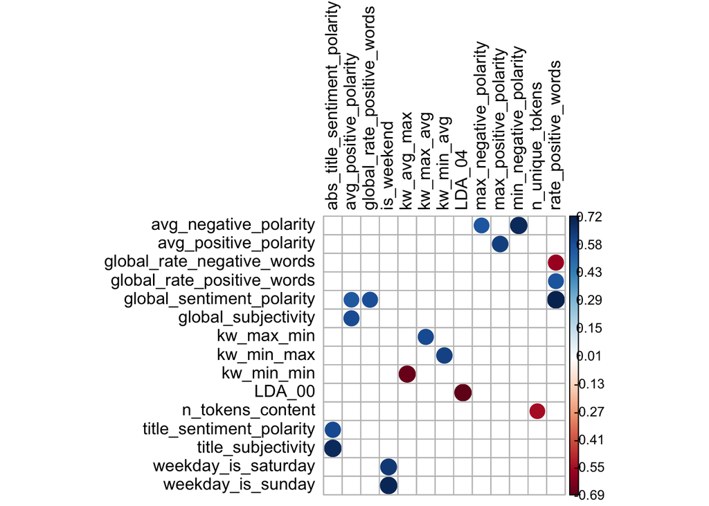

```r
#turn corr back into matrix in order to plot with corrplot
correlationMat <- reshape2::acast(corrDf, X1~X2, value.var="v")

#plot correlations visually
corrplot(correlationMat, is.corr=FALSE, tl.col="black", na.label=" ")
```

Correlation with Shares:

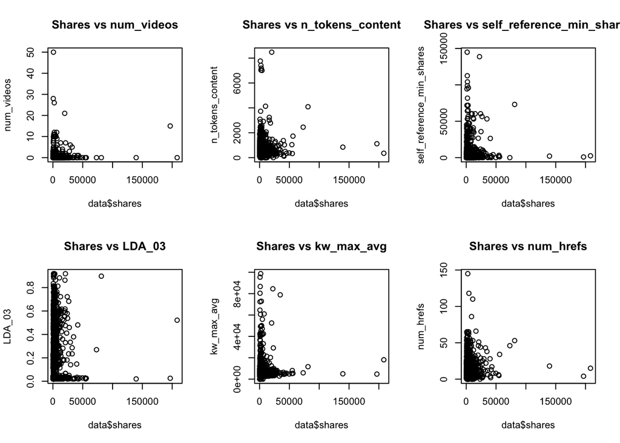

```r
sharesCor <- cor(data[ , colnames(data) != "shares"],  # Calculate correlations
                data$shares)

sharesCor <- data.frame(sharesCor)
sharesCor$names <- rownames(sharesCor)
rownames(sharesCor) <- NULL

sharesCor <- sharesCor %>%
  rename(corrcoeff=sharesCor) %>%
  arrange(desc(abs(corrcoeff))) %>%
  head(6)

par(mfrow=c(2,3))
for (i in sharesCor$names) {
  plot(data$shares, data[[i]], ylab = i, main = paste("Shares vs", i))
}
```

Understanding the distribution of the target variable

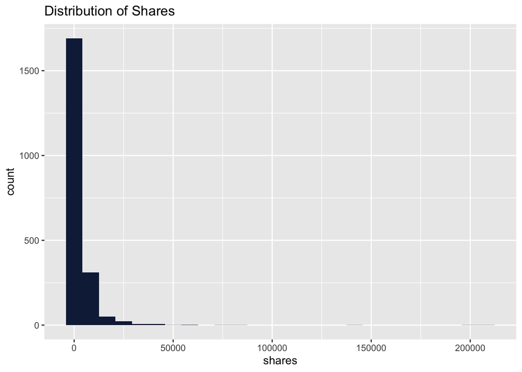

```r
ggplot(data) +
  aes(x = shares) +
  geom_histogram(bins = 26L, fill = "#112446") +
  labs(title = "Distribution of Shares") +
  theme_gray()
```

Now let’s analyze the affect of the different variables on the shares. Starting with the number of words in the title and how they affect the shares.

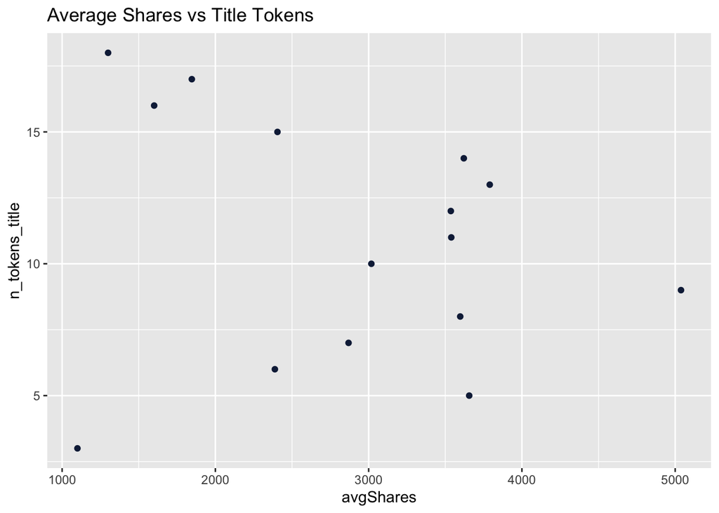

```r
data %>%
  group_by(n_tokens_title) %>%
  summarise(avgShares = mean(shares)) %>%
  ggplot() +
  aes(x = avgShares, y = n_tokens_title) +
  geom_point(shape = "circle", size = 1.5, colour = "#112446") +
  labs(title = "Average Shares vs Title Tokens") +
  theme_gray()
```

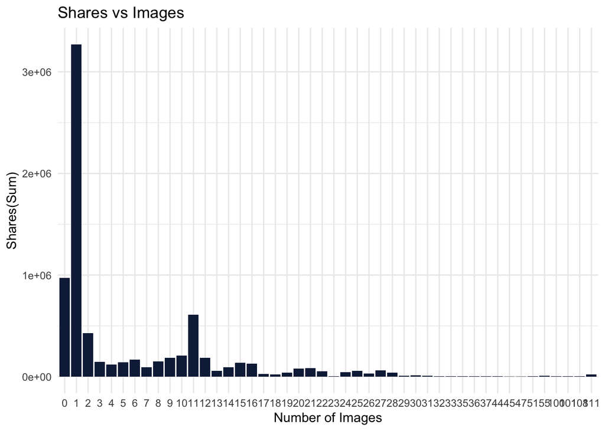

```r
data %>%
  group_by(factor(num_imgs)) %>%
  summarise(sumShares = sum(shares)) %>%
  ggplot() +
  aes(x = `factor(num_imgs)`, y = sumShares) +
  geom_col(fill = "#112446") +
  labs(title = "Shares vs Images", x = "Number of Images", y = "Shares(Sum)") +
  theme_minimal()
```

Expected Behavior : Less images do better.

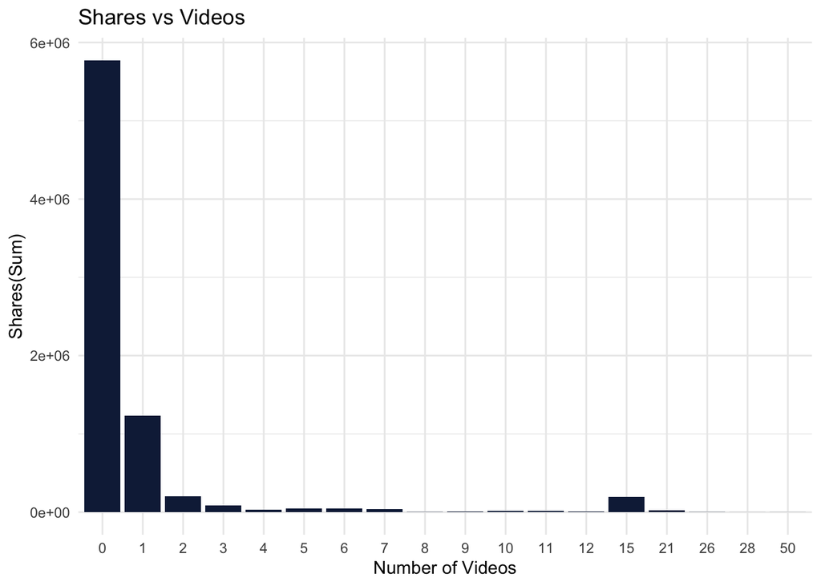

```r
data %>%
  group_by(factor(num_videos)) %>%
  summarise(sumShares = sum(shares)) %>%
  ggplot() +
  aes(x = `factor(num_videos)`, y = sumShares) +
  geom_col(fill = "#112446") +
  labs(title = "Shares vs Videos", x = "Number of Videos", y = "Shares(Sum)") +
  theme_minimal()
```

Expected Behavior: 0-1 Videos do the best.

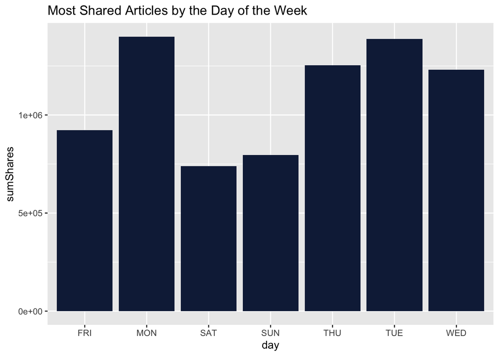

```r
mon <- data %>%
  select(starts_with("weekday_is_monday"), shares) %>%
  group_by(weekday_is_monday) %>%
  summarise(sumShares = sum(shares)) %>%
  rename(day = weekday_is_monday) %>%
  filter(day==1)
mon$day[mon$day==1] <- "MON"

tue <- data %>%
  select(starts_with("weekday_is_tuesday"), shares) %>%
  group_by(weekday_is_tuesday) %>%
  summarise(sumShares = sum(shares)) %>%
  rename(day = weekday_is_tuesday) %>%
  filter(day==1)
tue$day[tue$day==1] <- "TUE"


wed <- data %>%
  select(starts_with("weekday_is_wednesday"), shares) %>%
  group_by(weekday_is_wednesday) %>%
  summarise(sumShares = sum(shares)) %>%
  rename(day = weekday_is_wednesday) %>%
  filter(day==1)
wed$day[wed$day==1] <- "WED"


thu <- data %>%
  select(starts_with("weekday_is_thursday"), shares) %>%
  group_by(weekday_is_thursday) %>%
  summarise(sumShares = sum(shares)) %>%
  rename(day = weekday_is_thursday) %>%
  filter(day==1)
thu$day[thu$day==1] <- "THU"

fri <- data %>%
  select(starts_with("weekday_is_friday"), shares) %>%
  group_by(weekday_is_friday) %>%
  summarise(sumShares = sum(shares)) %>%
  rename(day = weekday_is_friday) %>%
  filter(day==1)
fri$day[fri$day==1] <- "FRI"

sat <- data %>%
  select(starts_with("weekday_is_saturday"), shares) %>%
  group_by(weekday_is_saturday) %>%
  summarise(sumShares = sum(shares)) %>%
  rename(day = weekday_is_saturday) %>%
  filter(day==1)
sat$day[sat$day==1] <- "SAT"

sun <- data %>%
  select(starts_with("weekday_is_sunday"), shares) %>%
  group_by(weekday_is_sunday) %>%
  summarise(sumShares = sum(shares)) %>%
  rename(day = weekday_is_sunday) %>%
  filter(day==1)
sun$day[sun$day==1] <- "SUN"

mon %>%
  bind_rows(tue, wed, thu, fri, sat, sun) %>%
  ggplot() +
  aes(x = day, y = sumShares) +
  geom_col(fill = "#112446") +
  labs(title = "Most Shared Articles by the Day of the Week") +
  theme_gray()
```

# Modeling

## Linear Regression

A simple linear regression refers to a linear equation that captures the relationship between a response variable, $Y$, and a predictor variable $X$. The relationship is modeled below:

$Y = \beta_0 + \beta_1X_1 +\epsilon i$

Where $\beta_0$ is the intercept and $\beta_1$ is the slope of the line. This relationship can be extended to the case in which the response variable is modeled as a function of more than one predictor variable. This is the case of a multiple linear regression, which is as follows:

$Y = \beta_0 + \beta_1X_1 + \beta_2X_2 + … + \beta_nX_n + \epsilon i$

Where $\beta_0$ is the intercept and all $\beta$ are slope coefficients. For both simple and multiple linear regression cases, the Method of Least Squares is widely used in summarizing the data. The least squares method minimizes values of $\beta_0$ and all $\beta_n$, seen below:

$\sum_{i = 1}^{n} (yi - \beta_0 - \sum_{j = 1}^{k} \beta_j x_{ij}^2)$

## Random Forest

The random forest model refers to an ensemble method of either classification or regression. In this case, we are predicting a continuous response variable, and are thus using the latter case. The random forest creates numerous trees from bootstrap samples of the data. Bootstrap samples are simply samples taken from the data and are of the same size (sample $n$ equals bootstrap $m$), meaning that an observation from the sample data could be used twice in the bootstrap sample, for example. A tree is fit to each bootstrap sample, and for each fit a random subset (generally $m = p/3$ predictors) of predictors is chosen. This is done with the tuning parameter mtry.

Generally speaking, random forests predict more accurately because the results of the fitted trees are averaged across all trees. This averaging reduces variance.

## Boosted Tree

Boosted tree models, like the random forest, are an ensemble tree-based method that can be used for classification or regression. Again, in our case, we are predicting a continuous response and are using regression.

Unlike the random forest, in the boosted tree method, trees are grown sequentially, and for each tree the residuals are treated as the response. This is exactly true for the first tree. Updated predictions can be modeled by the following:

$\hat{y} = \hat{y}(x) + \lambda \hat{y}^b (x)$